# WORD VECTORS AND PRESIDENTIAL DEBATES IN R

WW44SS

April 5, 2016

### SUMMARY

This continuation of [BIAS AND CONTEXT IN PRESIDENTIAL DEBATE TEXTS](https://rpubs.com/ww44ss/Debate_Text) and HEAT MAPS & LINGUISTICS OF DEBATE SPEECH in R, which focused on a “Bag of Words” approach to analyzing the text of Presidential Debates for the 2016 Election Cycle extends the analysis to include “sentiment” based on a word vectors model.

Word vectors, which rely on deep-learning based word-correlation analysis of texts with ~ billions of words, are well known to provide interesting linear structures in the word-vector space. The intention here is to explore these in relation to detecting bias and differences in political speech.

### DATA SOURCES AND METHODS

The text of the presidential debates are downloaded from the [UCSB Presidency Project](http://www.presidency.ucsb.edu/debates.php). Transcripts were pasted into Apple Pages and stored as unformatted .txt files.

Training word-vectors typically relies on corpora of ~billions of words, far more than the ~100,000 words spoken in the Debates. Hence rather than train the word vectors on the debate text, we’ll rely on the “pre-trained” **GloVe** vectors from [Jeffrey Pennington, Richard Socher, and Christopher D. Manning. 2014](http://nlp.stanford.edu/pubs/glove.pdf) and use them as a basis for analysis.

```r
    ##FILTER TEXT
    word.filter <- "gun"
```

### CANDIDATE WORD FREQUENCIES

We can check word frequency directly by tokenizing and counting single words. (Note: this is a partial duplication of the work done in the first analysis. But as the word vector analysis below leverages some of the output of this, it’s reproduced here in a slightly different format as a control of quality)

There are a total of 752 words in the combined vocabulary of the candidates.

| word | trump | sanders | clinton | rubio | cruz | all |
| --- | --- | --- | --- | --- | --- | --- |
| gun | 0 | 29 | 23 | 8 | 2 | 62 |
| guns | 6 | 13 | 7 | 8 | 5 | 39 |
| people | 5 | 21 | 9 | 3 | 1 | 39 |
| think | 1 | 12 | 7 | 0 | 0 | 20 |
| know | 2 | 2 | 12 | 1 | 1 | 18 |
| said | 1 | 4 | 4 | 1 | 4 | 14 |
| senator | 0 | 2 | 9 | 0 | 2 | 13 |
| president | 1 | 1 | 0 | 9 | 1 | 12 |
| state | 0 | 12 | 0 | 0 | 0 | 12 |
| look | 4 | 1 | 4 | 1 | 0 | 10 |
| america | 0 | 1 | 2 | 3 | 3 | 9 |
| immunity | 0 | 0 | 9 | 0 | 0 | 9 |
| right | 1 | 2 | 0 | 2 | 4 | 9 |
| second | 0 | 0 | 0 | 5 | 3 | 8 |
| wouldnt | 4 | 0 | 2 | 0 | 0 | 6 |
| funding | 0 | 0 | 0 | 5 | 0 | 5 |
| around | 3 | 1 | 0 | 0 | 0 | 4 |
| court | 0 | 0 | 0 | 0 | 4 | 4 |
| SUM | 169 | 561 | 587 | 167 | 234 | 1718 |

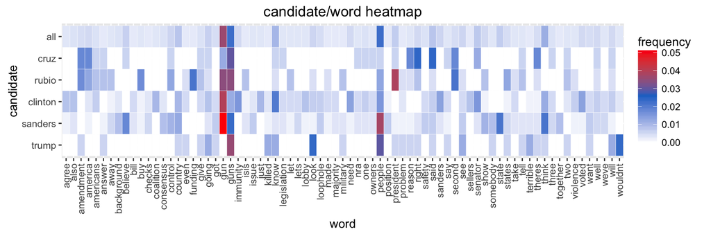

### WORD VECTOR ANALYSIS

The first step is to load the GloVe word vectors.

```r
    number.of.words <- 9999
    word.vector.file <- "glove.6B.300d.txt"
```

The analysis uses the first 9999 of the GloVe word vectors glove.6B.300d.txt. It tool 41.5 seconds to load the word vetors and put them into usable form.

#### WORD VECTOR SIMILARITY

Before delving into the full analysis, it’s helpful to look at vector representations of familiar word-pairs to help build an intuitive sense of how vector representations of words facilitate their coparison and analysis.

Vectors of individual words are easily extracted from the word vector data frame using simple *regular expressions* syntax.

```r
man.vec <- vector.normalize(word.vector.df[grep( "^man$", word.list), -1])
```

The vector $\textbf{man.vec}$ is normalized to unit length representing the word *man*.

```r
govern.vec <- vector.normalize(word.vector.df[grep( "^govern", word.list), -1])
```

creates a unit vector representing the following 9 words: *government, governor, governments, governing, governors, governmental, governance, governed,* and *govern*.

### CANDIDATE WORD VECTORS

As a first comparison, let’s explore representing the differences in candidate positions by the most common words of speech. As we’ve seen above, word frequencies vary significantly between candidates so perhaps some meaning can be extracted.

#### BAG OF WORDS AND WORD-VECTORS

Resulting vectors from the words 1 to 11 of the candidate “bag of words” filtered for comments containing *gun* and *9999* and from *glove.6B.300d.txt*.

Negative values are represented in red and positive values in green. We can see some patterns distinguishing candidates in the vectors themselves. If you squint you can see some similiarities and differences which are consistent with the above word frequency data. For instance, the $\textbf{sanders.vec}$ appears more similar to $\textbf{clinton.vec}$ than to $\textbf{rubio.vec}$. However, beyond these superficial comparisons, there’s little that can be inferred from these abstract representations.

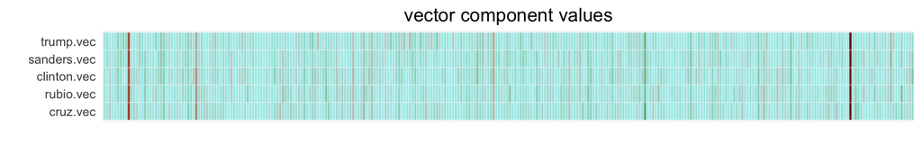

To emphasize differences, we can look at the variation from the mean of the candidate vectors. This better emphasizes differences between candidates, though, again, little can be inferred.

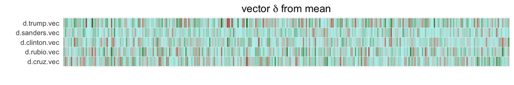

#### CANDIDATE COSINES

Resulting vectors from the words 1 to 11 of the candidate “bag of words” filtered for comments containing *gun* and *9999* and from *glove.6B.300d.txt*.

Candidate Vectors

| $\mathbf{a}$ | $\mathbf{b}$ | $\cos(\theta)$ | $\theta$ (mrad) |
| --- | --- | --- | --- |
| cruz | trump | 0.77 | 480 |
| sanders | trump | 0.84 | 400 |
| clinton | sanders | 0.92 | 280 |
| clinton | cruz | 0.85 | 390 |
| sanders | cruz | 0.84 | 400 |

### VECTOR WORD COMPARISONS TO CANDIDATE POSITIONS

Among the simplest comparisons of candidates is between their vectors and single words. In practice, hand-selected words did not prove very useful. Most single words, even those frequently used by in the debates, did not correlate well to candidate vectors.

#### *COUNTRY*, *PEOPLE*, AND *TAXES*

A comparison that was compelling is comparing condidates vectors to *“people”*, *“country”*, and *“tax”*.

Words 1 to 11  
Filter *gun*  
*9999* to *glove.6B.300d.txt*.

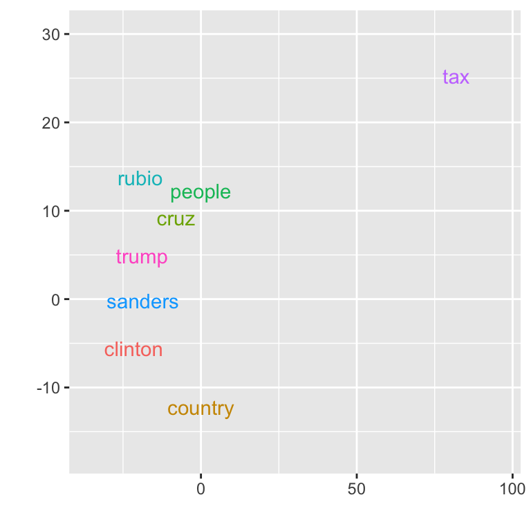

#### *TRUMP* AND *SANDERS*

Words 1 to 11  
Filter *gun*  
*9999* to *glove.6B.300d.txt*.

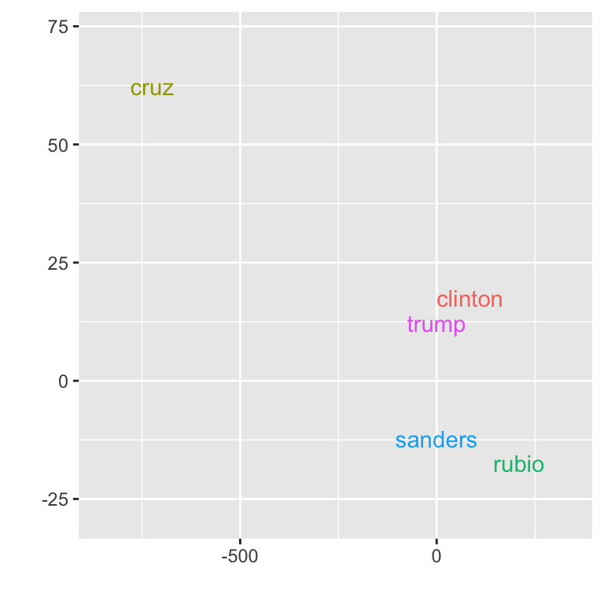

### BEST SINGLE WORD MATCHES

#### TRUMP

Words 1 to 11  
Filter *gun*  
*9999* to *glove.6B.300d.txt*.

| word | theta |
| --- | --- |
| people | 0.78 |
| they | 0.74 |
| just | 0.74 |
| those | 0.72 |
| them | 0.72 |
| all | 0.72 |
| so | 0.71 |
| going | 0.70 |
| we | 0.70 |
| come | 0.70 |

#### SANDERS

Words 1 to 11  
Filter *gun*  
*9999* to *glove.6B.300d.txt*.

| word | theta |
| --- | --- |
| gun | 0.75 |
| people | 0.70 |
| say | 0.69 |
| guns | 0.68 |
| that | 0.68 |
| they | 0.67 |
| what | 0.66 |
| so | 0.66 |
| even | 0.66 |
| believe | 0.65 |

#### CLINTON

Words 1 to 11  
Filter *gun*  
*9999* to *glove.6B.300d.txt*.

| word | theta |
| --- | --- |
| gun | 0.71 |
| know | 0.70 |
| say | 0.69 |
| want | 0.69 |
| n’t | 0.69 |
| what | 0.67 |
| so | 0.67 |
| why | 0.67 |
| should | 0.67 |
| get | 0.67 |

### COMPARE DIFFERENCES BETWEEN CANDIDATE VECTORS

We can also look for the words that close the difference between two vectors. For instance, what words best match.

#### SANDERS - TRUMP

Words 1 to 11  
Filter *gun*  
*9999* to *glove.6B.300d.txt*.

|  | word | dot.product |
| --- | --- | --- |
| 1 | gun | 0.42 |
| 2 | around | -0.35 |
| 3 | zones | -0.35 |
| 4 | amendment | 0.32 |
| 5 | opposes | 0.32 |
| 6 | firearms | 0.31 |
| 7 | argued | 0.30 |
| 8 | villages | -0.30 |
| 9 | state | 0.30 |
| 10 | asserted | 0.30 |

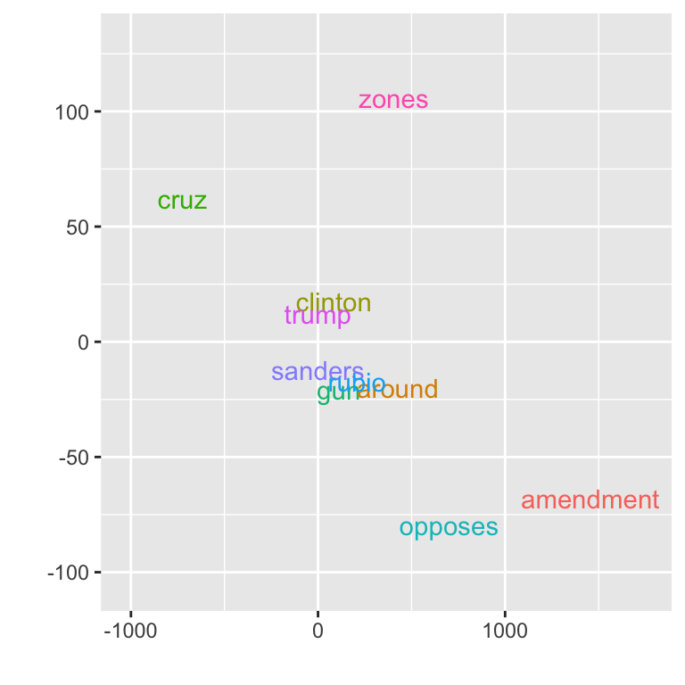

### TRUMP - CRUZ

Words 1 to 11  
Filter *gun*  
*9999* to *glove.6B.300d.txt*.

|  | word | dot.product |
| --- | --- | --- |
| 1 | amendment | -0.47 |
| 2 | upheld | -0.47 |
| 3 | argued | -0.45 |
| 4 | court | -0.44 |
| 5 | supreme | -0.41 |
| 6 | asserted | -0.40 |
| 7 | ruling | -0.39 |
| 8 | constitutional | -0.39 |
| 9 | judge | -0.39 |
| 10 | arguing | -0.38 |

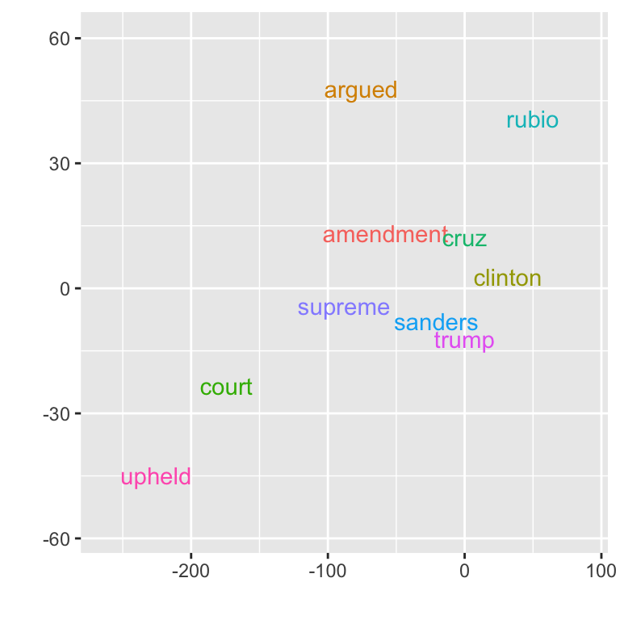

### CLINTON-SANDERS

Words 1 to 11  
Filter *gun*  
*9999* to *glove.6B.300d.txt*.

|  | word | dot.product |
| --- | --- | --- |
| 1 | immunity | 0.46 |
| 2 | senator | 0.45 |
| 3 | sanders | 0.44 |
| 4 | sen. | 0.40 |
| 5 | congressman | 0.36 |
| 6 | senators | 0.36 |
| 7 | voted | 0.36 |
| 8 | democrat | 0.36 |
| 9 | senate | 0.33 |
| 10 | lieberman | 0.33 |

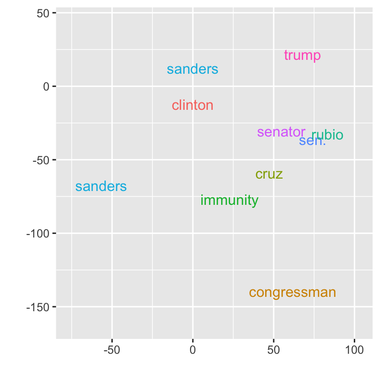

### COMPARE DIFFERENCES BETWEEN CANDIDATE VECTORS

We can also look for the words that close the difference between two vectors. For instance, what words best match.

### PARING: SANDERS + gun - CLINTON

Words 1 to 11  
Filter *gun*  
*9999* to *glove.6B.300d.txt*.

|  | word | dot.product |
| --- | --- | --- |
| 1 | gun | -0.93 |
| 2 | guns | -0.68 |
| 3 | rifle | -0.55 |
| 4 | weapon | -0.53 |
| 5 | firearms | -0.51 |
| 6 | pistol | -0.49 |
| 7 | cannon | -0.46 |
| 8 | assault | -0.45 |
| 9 | ammunition | -0.45 |
| 10 | machine | -0.43 |
| 11 | firing | -0.42 |
| 12 | shoot | -0.41 |
| 13 | rifles | -0.40 |
| 14 | battery | -0.39 |
| 15 | legislation | -0.39 |
| 16 | bullet | -0.39 |
| 17 | grenade | -0.39 |
| 18 | bullets | -0.39 |
| 19 | amendment | -0.38 |
| 20 | abortion | -0.38 |

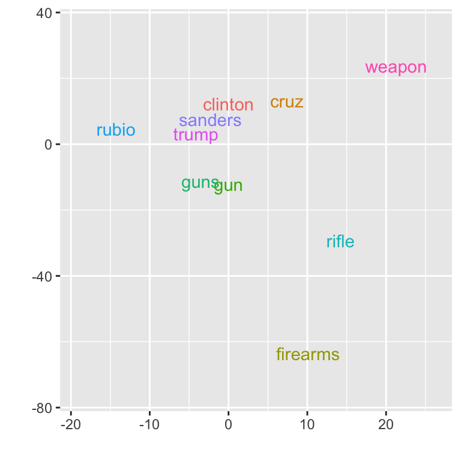